# m200_hw5_ahowe

Andrew Howe

May 6, 2015

## Extra Credit / Set up the data

|  | COMP | MORT | SURV |
| --- | --- | --- | --- |
| CEDARS.SINAI | 84697 | 4458 | 20193 |
| Kaiser.LA | 10396 | 38 | 1280 |
| HARBOR.UCLA | 4822 | 207 | 743 |
| OLIVE.VIEW.UCLA | 2690 | 84 | 419 |
| RONALD.REAGAN.UCLA | 27198 | 1065 | 4752 |
| SANTA.MONICA.UCLA | 20391 | 1135 | 5284 |

# Data Analysis

## R’s built in fisher.test()

```r
fisher.test( hospitalSummary )
```

This fails, with a complaint about running out of workspace : “Error in fisher.test(hospitalSummary) : FEXACT error 40. Out of workspace.”

This probably occurred because the factorials are enormous. Now, we’ll simulate the result with Monte-Carlo with this :

```r
fisher.test( hospitalSummary, simulate.p.value = TRUE)
```

```
##
##  Fisher's Exact Test for Count Data with simulated p-value (based
##  on 2000 replicates)
##
## data:  hospitalSummary
## p-value = 0.0004998
## alternative hypothesis: two.sided
```

The results of the Fisher’s test suggest a significant association between outcome and hospital location.

## Bootstraping Chi-squared and Kullback-Liebler Divergence

It is assumed here that “survival” means “survival status”.

Assumptions to fulfill :

The data is categorical; one of 6 hospitals and one of 3 statuses. The smallest number of observations in any location/status is sufficiently large (more than 5, according to stattrek.com.) The population is a random sample of hospitals (sort of.) The population is 10x the sample (stattrek.com; actually not quite sure what they mean by this.)

Hypotheses :

H-Null – The hospital and the outcome are independent.

H-AntiNull – The hospital and the outcome are related.

Chi-squared result :

```
## [1] 1444.933
```

KL result :

```
## [1] 1248.952
```

The results of the bootstrap indicate that a Chi Square value of 1444.9332 is highly unlikely with a p-value of 0 (zero means the bootstrap cannot accurately estimate how unlikely this observation is.)

The results of the bootstrap indicate that a KL value of 1248.9523 is highly unlikely with a p-value of 0 (zero means the bootstrap cannot accurately estimate how unlikely this observation is.)

It’s a pretty safe bet that the hospital has something to do with the outcome (or that certain hospitals attract people more likely to have certain outcomes due to factors unaccounted for in this data.)

## Relative Risk of Death Matrix

The assignment sheet states that COMP patients had complications secondary to the primary intervention, but does not indicate whether these patients died. It is assumed here that these patients did not die, and they are therefore lumped into the “survived” category for the purposes of comparing risk of fatalality after intervention.

### Fraction of deaths after interventions for life-threatening conditions

```
  CEDARS.SINAI          Kaiser.LA        HARBOR.UCLA
   0.040768921        0.003243982        0.035862786
```

### Relative Risk of Death Matrix

The way to read this is “the relative risk of death in the hospital *row name* is *table value* compared to *column name* (that is, divided by risk of death at *column name*).

|  | CEDARS.SINAI | Kaiser.LA | HARBOR.UCLA | OLIVE.VIEW.UCLA | RONALD.REAGAN.UCLA | SANTA.MONICA.UCLA |
| --- | --- | --- | --- | --- | --- | --- |
| CEDARS.SINAI | 1.00 | 12.57 | 1.14 | 1.55 | 1.26 | 0.96 |
| Kaiser.LA | 0.08 | 1.00 | 0.09 | 0.12 | 0.10 | 0.08 |
| HARBOR.UCLA | 0.88 | 11.06 | 1.00 | 1.36 | 1.11 | 0.85 |
| OLIVE.VIEW.UCLA | 0.65 | 8.11 | 0.73 | 1.00 | 0.82 | 0.62 |
| RONALD.REAGAN.UCLA | 0.79 | 9.94 | 0.90 | 1.23 | 1.00 | 0.76 |
| SANTA.MONICA.UCLA | 1.04 | 13.05 | 1.18 | 1.61 | 1.31 | 1.00 |

### Confidence Intervals

Neat. Histograms with 95% CIs. Too bad the labels are terrible.

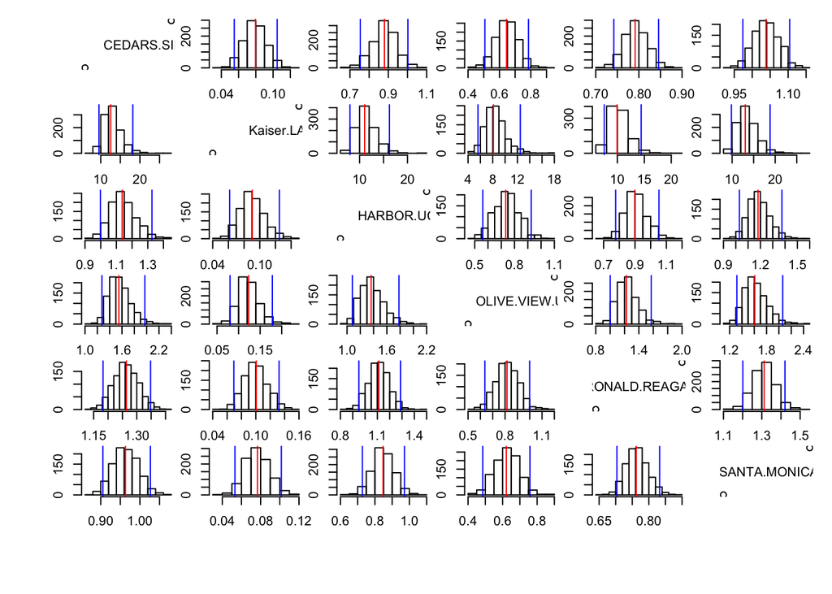

#### Lower 95% CI on Relative Risk of Death

|  | CEDARS.SINAI | Kaiser.LA | HARBOR.UCLA | OLIVE.VIEW.UCLA | RONALD.REAGAN.UCLA | SANTA.MONICA.UCLA |
| --- | --- | --- | --- | --- | --- | --- |
| CEDARS.SINAI |  | 9.55 | 1.00 | 1.27 | 1.18 | 0.91 |
| Kaiser.LA | 0.05 |  | 0.06 | 0.08 | 0.07 | 0.05 |
| HARBOR.UCLA | 0.75 | 8.00 |  | 1.08 | 0.95 | 0.73 |
| OLIVE.VIEW.UCLA | 0.51 | 5.61 | 0.56 |  | 0.64 | 0.48 |
| RONALD.REAGAN.UCLA | 0.74 | 7.56 | 0.78 | 1.00 |  | 0.70 |
| SANTA.MONICA.UCLA | 0.97 | 9.84 | 1.03 | 1.32 | 1.20 |  |

#### Upper 95% CI on Relative Risk of Death

|  | CEDARS.SINAI | Kaiser.LA | HARBOR.UCLA | OLIVE.VIEW.UCLA | RONALD.REAGAN.UCLA | SANTA.MONICA.UCLA |
| --- | --- | --- | --- | --- | --- | --- |
| CEDARS.SINAI |  | 18.19 | 1.33 | 1.97 | 1.35 | 1.03 |
| Kaiser.LA | 0.10 |  | 0.13 | 0.18 | 0.13 | 0.10 |
| HARBOR.UCLA | 1.00 | 16.24 |  | 1.78 | 1.29 | 0.97 |
| OLIVE.VIEW.UCLA | 0.78 | 12.48 | 0.93 |  | 1.00 | 0.76 |
| RONALD.REAGAN.UCLA | 0.85 | 14.42 | 1.05 | 1.57 |  | 0.83 |
| SANTA.MONICA.UCLA | 1.10 | 18.81 | 1.37 | 2.06 | 1.42 |  |

### Null Hypothesis Testing P-Values for Risk Ratio

|  | CEDARS.SINAI | Kaiser.LA | HARBOR.UCLA | OLIVE.VIEW.UCLA | RONALD.REAGAN.UCLA | SANTA.MONICA.UCLA |
| --- | --- | --- | --- | --- | --- | --- |
| CEDARS.SINAI |  | 0.00 | 0.05 | 0.00 | 0.00 | 0.28 |
| Kaiser.LA | 0.00 |  | 0.00 | 0.00 | 0.00 | 0.00 |
| HARBOR.UCLA | 0.05 | 0.00 |  | 0.01 | 0.13 | 0.02 |
| OLIVE.VIEW.UCLA | 0.00 | 0.00 | 0.01 |  | 0.03 | 0.00 |
| RONALD.REAGAN.UCLA | 0.00 | 0.00 | 0.13 | 0.03 |  | 0.00 |
| SANTA.MONICA.UCLA | 0.28 | 0.00 | 0.02 | 0.00 | 0.00 |  |

Zero in the table above means that the resampling was unable to determine a value for this bootstrap, and thus it is significant at a p < 0.001 level.

# References

Healthcare.gov

null hypothesis http://xkcd.com/892/

correlation http://www.treelobsters.com/2012/04/361-this-that-other-thing.html

Made with R

[output not shown]